# Question2

## 2) BONUS: For an upcoming presentation, you are asked to predict total gate revenue for the entire NBA Playoffs. You should use the win probabilities data provided in this file and the Hypothetical Playoff Gate Data tab in this file to answer part b of the question.

### a) As a primer, let’s think about an individual series. Team East1 plays Team East8 in the First Round. Suppose the probability that East1 defeats East8 at home (8 @ 1) is p_H, and the probability that East1 defeats East8 on the road (1 @ 8) is p_A. In terms of p_H and p_A, what is the probability that the series goes exactly N games for N in {4,5,6,7}, regardless of winner? Please give closed-form analytical solutions.

```python
Suppose w(n) is the probability that East1 wins the game in n games, l(n) is the probability that East1 loses in n games, and f(n) is the probability the series finished in n games. So f(n) = w(n) + l(n)
    w4 = p_H**2 * p_A**2
    w5 = (2*p_H*(1-p_H)*p_A**2+2*p_H**2*p_A*(1-p_A))*p_H
    w6 = (3*p_H*(1-p_H)**2*p_A**2+p_H**3*(1-p_A)**2+3*2*p_H**2*(1-p_H)*p_A*(1-p_A))*p_A
    w7 = ((1-p_H)**3*p_A**3
          + p_H**3*(1-p_A)**3
          + 9*p_H**2*(1-p_H)*p_A*(1-p_A)**2
          + 9*p_H*(1-p_H)**2*p_A**2*(1-p_A)) * p_H
    l4 = (1-p_H)**2 * (1-p_A)**2
    l5 = (2*(1-p_H)*p_H*(1-p_A)**2+2*(1-p_H)**2*(1-p_A)*p_A)*(1-p_H)
    l6 = (3*(1-p_H)*p_H**2*(1-p_A)**2+(1-p_H)**3*p_A**2+3*2*(1-p_H)**2*p_H*(1-p_A)*p_A)*(1-p_A)
    l7 = (p_H**3*(1-p_A)**3
          + (1-p_H)**3*p_A**3
          + 9*(1-p_H)**2*p_H*(1-p_A)*p_A**2
          + 9*(1-p_H)*p_H**2*(1-p_A)**2*p_A) * (1-p_H)
F4 = w4 + l4
F5 = w5 + l5
F6 = w6 + l6
F7 = w7 + l7
```

### b) Now suppose that the regular season has just concluded and the NBA playoff picture is set. Team Finance has forecasted gate revenue per game for every team in each possible round – these per-game forecasts for each (team, round) combination are given in the Hypothetical Playoff Gate Data tab in the attached Excel file. Further suppose you are given win_probabilities.csv, which describes the probability that a given team defeats any other team, either at home or on the road. (The format of the probabilities in each row may not be standard.) Note that there is no re-seeding in the NBA Playoffs and that each series follows a 2-2-1-1-1 format. If equal seeds make the Finals, suppose the West team has home court advantage; otherwise, suppose the better seed has home court. Build a playoff simulator that tracks gate revenue using this data. (Assume each game is independent.) Please include any code or any additional materials you used to build your simulator in a zip folder.

```python
'''
Here I write a simulator as season()
It will simulate the Playoffs and return the results of each round.
Also a function called revenue(teamnumber) could return the total gate revenue
of a team, given a certain simulator.
'''

import numpy as np
from random import random
from openpyxl import load_workbook, Workbook
import matplotlib.pyplot as plt


wb = load_workbook(filename = 'win_probabilities.xlsx')
ws = wb['win_probabilities.csv']
wins = np.ndarray(shape=(16,16), dtype=float)
for i in range(16):
    for j in range(16):
        wins[i][j] = 0.0
i = 1

# west team will have small numbers

while i < len(ws['A']):
    if ws['A'][i].value[0] == 'W':
        home = int(ws['A'][i].value[4]) - 1
    else:
        home = int(ws['A'][i].value[4]) + 7
    if ws['B'][i].value[0] == 'W':
        away = int(ws['B'][i].value[4]) - 1
    else:
        away = int(ws['B'][i].value[4]) + 7
    wins[home][away] = ws['C'][i].value
    wins[away][home] = 1-ws['D'][i].value
    i += 1




wb = load_workbook(filename = 'Business-Track-Application-Datasets.xlsx')
ws = wb['Hypothetical Playoff Gate Data']
rev = np.ndarray(shape=(16,4), dtype=float)
for i in range(3, 19):
    for j in range(2, 6):
        if i >= 11:
            k = i - 8
        else:
            k = i + 8
        rev[k-3][j-2] = ws[i][j].value


def htclear(ht):
    # clean hashtable
    ht = None
    from random import random
    ht = dict()
    for i in range(4):
        ht[i] = dict()
        for j in range(16):
            ht[i][j] = 0
    return ht
ht = dict()
ht = htclear(ht)



def t2wins(ph, pa):
    # calculate the probability the game will finish in N games
    pa = 1 - pa
    w4 = ph**2 * pa**2
    w5 = (2*ph*(1-ph)*pa**2+2*ph**2*pa*(1-pa))*ph
    w6 = (3*ph*(1-ph)**2*pa**2+ph**3*(1-pa)**2+3*2*ph**2*(1-ph)*pa*(1-pa))*pa
    w7 = ((1-ph)**3*pa**3
          + ph**3*(1-pa)**3
          + 9*ph**2*(1-ph)*pa*(1-pa)**2
          + 9*ph*(1-ph)**2*pa**2*(1-pa)) * ph
    ph, pa = 1-ph, 1-pa
    w4 += ph**2 * pa**2
    w5 += (2*ph*(1-ph)*pa**2+2*ph**2*pa*(1-pa))*ph
    w6 += (3*ph*(1-ph)**2*pa**2+ph**3*(1-pa)**2+3*2*ph**2*(1-ph)*pa*(1-pa))*pa
    w7 += ((1-ph)**3*pa**3
          + ph**3*(1-pa)**3
          + 9*ph**2*(1-ph)*pa*(1-pa)**2
          + 9*ph*(1-ph)**2*pa**2*(1-pa)) * ph

    return [w4, w5, w6, w7]


def macths(tt1,tt2):
    # calculate a macth of two certain teams
    if (tt2 < tt1 and tt1 < 8) or (tt2 >= 8 and tt1 > tt2) or (tt2 + 8 < tt1):
        t1, t2 = tt2, tt1
    else:
        t1, t2 = tt1, tt2

    t1wins, t2wins = 0, 0
    t1h, t2h = 0, 0
    i = 0
    while t1wins<4 and t2wins<4:
        if i==0 or i==1 or i==4 or i==6:
            p = wins[t1][t2]
            flag = True
        else:
            p = 1 - wins[t2][t1]
            flag = False
        if random() < p:
            t1wins += 1
            if flag:
                t1h += 1
            else:
                t2h += 1
        else:
            t2wins += 1
            if flag:
                t1h += 1
            else:
                t2h += 1
        i += 1
    if t1wins == 4:
        winner = t1
    else:
        winner = t2
    j = 0
    while j < 3 and ht[j][t1] != 0:
        j += 1
    ht[j][t1] = t1h
    ht[j][t2] = t2h
    return winner


def season():
    # this is the main simulator for the Playoffs
    tlist = list(range(16))
    round_one_win_list = []
    for i in range(4):
        round_one_win_list.append(macths(tlist[i],tlist[7-i]))
    for i in range(4):
        round_one_win_list.append(macths(tlist[8+i],tlist[15-i]))
    round_two_win_list = []
    for i in range(2):
        round_two_win_list.append(macths(round_one_win_list[i],round_one_win_list[3-i]))
    for i in range(2):
        round_two_win_list.append(macths(round_one_win_list[4+i],round_one_win_list[7-i]))
    round_three_win_list = []
    round_three_win_list.append(macths(round_two_win_list[0],round_two_win_list[1]))
    round_three_win_list.append(macths(round_two_win_list[2],round_two_win_list[3]))
    round_four_win_list = macths(round_three_win_list[0],round_three_win_list[1])
    return round_one_win_list, round_two_win_list, round_three_win_list, round_four_win_list

def revenue(t):
    # a revenue function, which will return a certain team total gate revenue given a ceratin
    # simulator
    total = 0
    for i in range(4):
        total += rev[t][i] * ht[i][t]
    return total
```

### c) How do you propose to present a solution to the team? You want to ensure the team understands that there is a relatively wide distribution of possible outcomes. What is the solution?

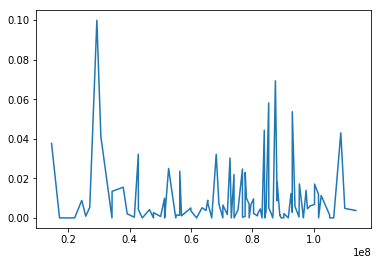

```
This is the distribution of the total revenue, as we can see here, the ourcomes are in a very large range.
```

```python
# show a distribution for question c

n = 100000
dis = []
for i in range(n):
    season()
    dis.append(revenue(0))
    ht = htclear(ht)
dis.sort()
htdis = dict()
for ele in dis:
    if ele not in htdis:
        htdis[ele] = 1
    else:
        htdis[ele] += 1
x = []
y = []
n = len(dis)
for ele in htdis:
    x.append(ele)
    y.append(htdis[ele]/n)
yy = [i for _,i in sorted(zip(y,x))]
x.sort()
plt.plot(x, y)
plt.show()
print('This is the distribution of the total revenue, as we can see here, the ourcomes are in a very large range.')
```

### d) What is the probability that West1 meets East1 in the Finals? What is the expected total Playoffs gate revenue if West1 meets East1 in the Finals? What if West1 does not meet East1 in the Finals? How does your solution change if – independent of all other series – East5 defeats East4 in the First Round? You don’t know how many games the series went; you just know the outcome.

#### What is the probability that West1 meets East1 in the Finals?

```python
n = 1000000
count = 0.0
dis = []
for i in range(n):
    if season()[2] == [0,8]:
        count += 1
        dis.append(revenue(0))
    ht = htclear(ht)

print('The probability that West1 meets East1 in the Finals : ', count/n)
```

```
The probability that West1 meets East1 in the Finals :  0.38901
```

#### What is the expected total Playoffs gate revenue if West1 meets East1 in the Finals?

```python
print('The expected total Playoffs gate revenue if West1 meets East1 in the Finals : ', np.mean(dis))
```

```
The expected total Playoffs gate revenue if West1 meets East1 in the Finals :  83899660.2889
```

#### What if West1 does not meet East1 in the Finals?

```python
n = 1000000
count = 0.0
dis = []
for i in range(n):
    if not(season()[2] == [0,8]):
        count += 1
        dis.append(revenue(0))
    ht = htclear(ht)
print('The probability West1 does not meet East1 in the Finals : ', count/n)
print('The expected total Playoffs gate revenue if West1 does not meet East1 in the Finals : ', np.mean(dis))
```

```
The probability West1 does not meet East1 in the Finals :  0.61032
The expected total Playoffs gate revenue if West1 does not meet East1 in the Finals :  60402041.8187
```

#### How does your solution change if – independent of all other series – East5 defeats East4 in the First Round?

```python
n = 1000000
count = 0.0
dis = []
i = 0
while i < n:
    a,b,c,d = season()
    if (5 in a):
        i += 1
        if not(c == [0,8]):
            count += 1
            dis.append(revenue(0))
    ht = htclear(ht)
print('The probability : ', count/n)
print('The expected total Playoffs gate revenue : ', np.mean(dis))
```

```
The probability :  0.622346
The expected total Playoffs gate revenue :  59686798.998
```